# **Data Science con `R`**

Instituto de Estadística PUCV - Magister en Estadística

Dae-Jin Lee < dlee@bcamath.org >

# Casos de Estudio

## E-mail spam

Los datos para este ejemplo consisten en información de 4601 mensajes de correo electrónico, en un estudio para tratar de predecir si el correo electrónico era correo no deseado o “spam”. El objetivo era diseñar un detector automático de spam que pudiera filtrar el spam antes de obstruir los buzones de correo de los usuarios. Para todos los 4601 mensajes de correo electrónico, el verdadero resultado (tipo de correo electrónico) de correo electrónico o spam está disponible, junto con las frecuencias relativas de 57 de las palabras más comunes y signos de puntuación en el mensaje de correo electrónico. Este es un problema de aprendizaje supervisado, con el resultado de la variable de clase email/spam. También se le llama problema de clasificación.

```r
library(kernlab)
library(caret)
set.seed(12345)
data(spam)
?spam
head(spam)
```

| make | address | all | num3d | our | over | remove | internet | order | mail | receive | will | people | report | addresses | free | business | email | you | credit | your | font | num000 | money | hp | hpl | george | num650 | lab | labs | … |
| --- | --- | --- | --- | --- | --- | --- | --- | --- | --- | --- | --- | --- | --- | --- | --- | --- | --- | --- | --- | --- | --- | --- | --- | --- | --- | --- | --- | --- | --- | --- |
| 0.00 | 0.64 | 0.64 | 0 | 0.32 | 0.00 | 0.00 | 0.00 | 0.00 | 0.00 | 0.00 | 0.64 | 0.00 | 0.00 | 0.00 | 0.32 | 0.00 | 1.29 | 1.93 | 0.00 | 0.96 | 0 | 0.00 | 0.00 | 0 | 0 | 0 | 0 | 0 | 0 | … |
| 0.21 | 0.28 | 0.50 | 0 | 0.14 | 0.28 | 0.21 | 0.07 | 0.00 | 0.94 | 0.21 | 0.79 | 0.65 | 0.21 | 0.14 | 0.14 | 0.07 | 0.28 | 3.47 | 0.00 | 1.59 | 0 | 0.43 | 0.43 | 0 | 0 | 0 | 0 | 0 | 0 | … |
| 0.06 | 0.00 | 0.71 | 0 | 1.23 | 0.19 | 0.19 | 0.12 | 0.64 | 0.25 | 0.38 | 0.45 | 0.12 | 0.00 | 1.75 | 0.06 | 0.06 | 1.03 | 1.36 | 0.32 | 0.51 | 0 | 1.16 | 0.06 | 0 | 0 | 0 | 0 | 0 | 0 | … |
| 0.00 | 0.00 | 0.00 | 0 | 0.63 | 0.00 | 0.31 | 0.63 | 0.31 | 0.63 | 0.31 | 0.31 | 0.31 | 0.00 | 0.00 | 0.31 | 0.00 | 0.00 | 3.18 | 0.00 | 0.31 | 0 | 0.00 | 0.00 | 0 | 0 | 0 | 0 | 0 | 0 | … |
| 0.00 | 0.00 | 0.00 | 0 | 0.63 | 0.00 | 0.31 | 0.63 | 0.31 | 0.63 | 0.31 | 0.31 | 0.31 | 0.00 | 0.00 | 0.31 | 0.00 | 0.00 | 3.18 | 0.00 | 0.31 | 0 | 0.00 | 0.00 | 0 | 0 | 0 | 0 | 0 | 0 | … |
| 0.00 | 0.00 | 0.00 | 0 | 1.85 | 0.00 | 0.00 | 1.85 | 0.00 | 0.00 | 0.00 | 0.00 | 0.00 | 0.00 | 0.00 | 0.00 | 0.00 | 0.00 | 0.00 | 0.00 | 0.00 | 0 | 0.00 | 0.00 | 0 | 0 | 0 | 0 | 0 | 0 | … |

```r
# Split the data into a training/test set by 60% training/40% test.
inTrain <- createDataPartition(y = spam$type, p=0.6, list=FALSE)
training <- spam[inTrain,]
testing <- spam[-inTrain,]
```

El objetivo es probar tres algoritmos diferentes de aprendizaje supervisado que podrían utilizarse potencialmente como un filtro de spam. Esencialmente queremos ver qué algoritmo tiene la mejor capacidad de predecir un email de spam dados ciertos criterios.

```r
library(randomForest) # randomForest method
library(MASS) # linear discrimant analysis
library(nnet) # neural network

#set up the training control
tr_ctrl = trainControl(method = "repeatedcv",number = 10,repeats = 10)


#train the models
forest_train = train(type ~ .,
               data=training,
               method="rf",
               trControl=tr_ctrl)

lda_train = train(type ~ .,
               data=training,
               method="lda",
               trControl=tr_ctrl)

nnet_train = train(type ~ .,
               data=training,
               method="nnet",
               trControl=tr_ctrl)
```

**Resultados**

Ahora que los modelos están entrenados, los probamos contra el conjunto de test. La herramienta `confusionMatrix()` muestra los resultados y las estadísticas relevantes para cada modelo.

```r
pred_forest = predict(forest_train, testing[,-58])
pred_lda = predict(lda_train, testing[,-58])
pred_nnet = predict(nnet_train, testing[,-58])
```

```r
confusionMatrix(pred_forest,testing$type)
confusionMatrix(pred_lda,testing$spam)
confusionMatrix(pred_nnet,testing$spam)
```

[output not shown]

La opción `method` permite ajustar otros modelos como `glm` (para la regresión logística) ó `gam` (para modelos aditivos generalizados). [Ver tutorial `caret`](http://topepo.github.io/)

# Material extra

## Análisis Cluster

El análisis de cluster es una técnica cuya idea básica es agrupar un conjunto de observaciones en un número dado de clusters o grupos. Este agrupamiento se basa en la idea de distancia o similitud entre las observaciones. Por tanto, la obtención de dichos clusters depende del criterio o distancia considerados.

Ejemplos de distancias:

- **Distancia euclídea:** Dados dos objetos $I_1$ e $I_2$ medidos según dos variables $x_1$ y $x_2$, la distancia euclídea entre ambos es
  $$d_{I_1,I_2} = \sqrt{(x_{11} - x_{21})^2+(x_{12} - x_{22})^2}$$
  Con $p$ dimensiones
  $$d_{I_1,I_2} = \sqrt{\sum_{i=1}^{p}(x_{1k} - x_{2k})^2}$$
- **Distancia de Mahalanobis:**

$$d_{I_1,I_2} = (x_i - x_j)^{\prime} W^{-1} (x_i - x_j)$$
donde $W$ es la matriz de covarianzas entre las variables. De este modo, las variables se ponderan según el grado de relación que exista entre ellas, es decir, si están más o menos correlacionadas. Si la correlación es nula y las variables están estandarizadas, se obtiene la distancia euclídea.

- **Distancia de Minkowski:**
  $$d_{I_1,I_2}^2 = \left[ \sum_{k} |x_{ik} - x_{ij} |^m \right]^{1/m}$$
  donde $m$ en un número natural, si $m=1$ la distancia es en valor absoluto y $m=2$ la euclídea.

### Métodos de cluster jerárquicos

En la práctica, no se pueden examinar todas las posibilidades de agrupar los elementos, incluso con los ordenadores más rápidos. Una solución se encuentra en los llamados métodos jerárquicos.

- *Métodos aglomerativos:* se comienza con los objetos o individuos de modo individual; de este modo, se tienen tantos clusters iniciales como objetos. Luego se van agrupando de modo que los primeros en hacerlo son los más similares y al final, todos los subgrupos se unen en un único cluster.
- *Métodos divisivos o de particionado:* al contrario. Se parte de un grupo único con todas las observaciones y se van dividiendo según lo lejanos que estén.

En cualquier caso, de ambos métodos se deriva un **dendograma**, que es un gráfico que ilustra cómo se van haciendo las subdivisiones o los agrupamientos, etapa a etapa.

Consideramos aquí los métodos aglomerativos con diferentes métodos de unión (linkage methods). Los más importantes son:

1. Mínima distancia o vecino más próximo.
2. Máxima distancia o vecino más lejano.
3. Distancia media (average distance).

Se puede observar que, de este modo, se define una posible distancia entre dos clusters: la correspondiente a la pareja de elementos más cercana, la más lejana o la media de todas las posibles parejas de elementos de ambos clusters.

### Métodos no jerárquicos

Se usan para agrupar objetos, pero no variables, en un conjunto de $k$ clusters ya predeterminado. No se tiene que especificar una matriz de distancias, lo cual entre otras razones permite trabajar con un número de datos mayor que en el caso de los métodos jerárquicos.

Se parte de un conjunto inicial de clusters elegidos al azar, que son los representantes de todos ellos; luego se van cambiando de modo iterativo. Se usa habitualmente el método de las $k$-medias.

**Método de las k-medias** permite asignar a cada observación el cluster que se encuentra más próximo en términos del centroide (media). En general, la distancia empleada es la euclídea.

Pasos:

1. Se toman al azar $k$ clusters iniciales.
2. Para el conjunto de observaciones, se vuelve a calcular las distancias a los centroides de los clusters y se reasignan a los que estén más próximos. Se vuelven a recalcular los centroides de los $k$ clusters después de las reasignaciones de los elementos.
3. Se repiten los dos pasos anteriores hasta que no se produzca ninguna reasignación, es decir, hasta que los elementos se estabilicen en algún grupo. Usualmente, se especifican $k$ centroides iniciales y se procede al paso (2) y, en la práctica, se observan la mayor parte de reasignaciones en las primeras iteraciones.

### Ejemplos:

En este conjunto de datos se observa la composición de diferentes vinos.

```r
# install.packages('rattle')
data(wine, package='rattle')
head(wine)
```

| Type | Alcohol | Malic | Ash | Alcalinity | Magnesium | Phenols | Flavanoids | Nonflavanoids | Proanthocyanins | Color | Hue | Dilution | Proline |
| --- | --- | --- | --- | --- | --- | --- | --- | --- | --- | --- | --- | --- | --- |
| 1 | 14.23 | 1.71 | 2.43 | 15.6 | 127 | 2.80 | 3.06 | 0.28 | 2.29 | 5.64 | 1.04 | 3.92 | 1065 |
| 1 | 13.20 | 1.78 | 2.14 | 11.2 | 100 | 2.65 | 2.76 | 0.26 | 1.28 | 4.38 | 1.05 | 3.40 | 1050 |
| 1 | 13.16 | 2.36 | 2.67 | 18.6 | 101 | 2.80 | 3.24 | 0.30 | 2.81 | 5.68 | 1.03 | 3.17 | 1185 |
| 1 | 14.37 | 1.95 | 2.50 | 16.8 | 113 | 3.85 | 3.49 | 0.24 | 2.18 | 7.80 | 0.86 | 3.45 | 1480 |
| 1 | 13.24 | 2.59 | 2.87 | 21.0 | 118 | 2.80 | 2.69 | 0.39 | 1.82 | 4.32 | 1.04 | 2.93 | 735 |
| 1 | 14.20 | 1.76 | 2.45 | 15.2 | 112 | 3.27 | 3.39 | 0.34 | 1.97 | 6.75 | 1.05 | 2.85 | 1450 |

Siempre es recomendable estandarizar las variables

```r
wine.stand <- scale(wine[-1])  # To standarize the variables

# K-Means
k.means.fit <- kmeans(wine.stand, 3) # k = 3
```

```r
attributes(k.means.fit)
```

```
## $names
## [1] "cluster"      "centers"      "totss"        "withinss"
## [5] "tot.withinss" "betweenss"    "size"         "iter"
## [9] "ifault"
##
## $class
## [1] "kmeans"
```

[output not shown]

[output not shown]

[output not shown]

Una pregunta fundamental es cómo determinar el valor del parámetro $k$. Si consideramos el porcentaje de varianza explicado como una función del número de grupos:

Uno debe elegir un número de grupos de modo que la adición de otro grupo no da mucho mejor modelado de los datos. Más precisamente, si se traza el porcentaje de varianza explicado por los conglomerados en función del número de racimos, los primeros grupos agregarán mucha información (explican mucha varianza), pero en algún momento la ganancia marginal disminuirá, dando un ángulo en la gráfico. El número de racimos se elige en este punto, de ahí el “criterio del codo”.

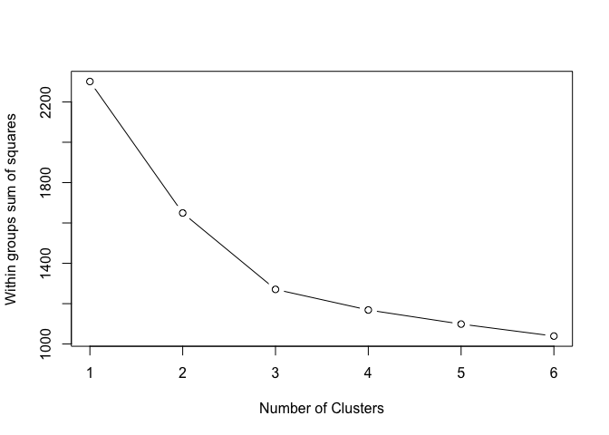

```r
wssplot <- function(data, nc=15, seed=1234){
  wss <- (nrow(data)-1)*sum(apply(data,2,var))
  for (i in 2:nc){
    set.seed(seed)
    wss[i] <- sum(kmeans(data, centers=i)$withinss)}
  plot(1:nc, wss, type="b", xlab="Number of Clusters",
       ylab="Within groups sum of squares")}

wssplot(wine.stand, nc=6)
```

La `library(cluster)` permite (con el paso previo de un PCA) representar los clusters en 2 dimensiones

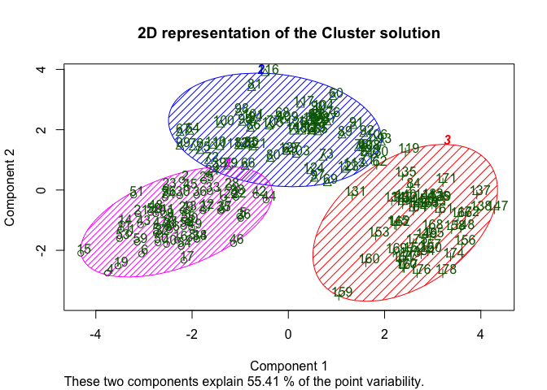

```r
library(cluster)
clusplot(wine.stand, k.means.fit$cluster,
         main='2D representation of the Cluster solution',
         color=TRUE, shade=TRUE,
         labels=2, lines=0)
```

Sabiendo que hay tres tipos de vinos `wine$Type`, podemos calcular una matriz de confusión

```r
table(wine$Type)
```

```
##
##  1  2  3
## 59 71 48
```

```r
table(wine[,1],k.means.fit$cluster)
```

```
##
##      1  2  3
##   1 59  0  0
##   2  3 65  3
##   3  0  0 48
```

**Cluster jerarquico**

Los métodos jerárquicos utilizan una matriz de distancia como una input para el algoritmo de agrupación. La elección de una métrica apropiada influirá en la forma de los clusters, ya que algunos elementos pueden estar cerca uno del otro según una distancia y más lejos de acuerdo con otro.

```r
d <- dist(wine.stand, method = "euclidean") # Euclidean distance matrix.
```

Ward’s minimum variance criterion minimizes the total within-cluster variance

```r
H.fit <- hclust(d, method="ward")
```

```
## The "ward" method has been renamed to "ward.D"; note new "ward.D2"
```

```r
class(H.fit)
```

```
## [1] "hclust"
```

La opcion `plot` de un objeto `hclust` nos devuelve el dendograma:

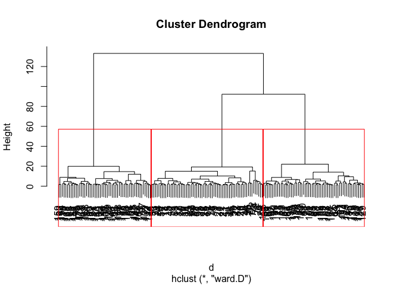

```r
plot(H.fit) # display dendogram
groups <- cutree(H.fit, k=3) # cut tree into 5 clusters
# draw dendogram with red borders around the 5 clusters
rect.hclust(H.fit, k=3, border="red")
```

```r
table(wine[,1],groups)
```

```
##    groups
##      1  2  3
##   1 58  1  0
##   2  7 58  6
##   3  0  0 48
```